# **Loan Default Prediction**

## **Problem Definition**

### **The Context:**

In the contemporary landscape of retail banking, a significant proportion of profits stems from interest accrued through home loans, primarily extended to customers with regular or high income. However, the specter of loan defaulters poses a considerable threat to banks, as non-performing assets (NPAs) can substantially erode profits. Therefore, the approval process for these loans is a multifaceted challenge, traditionally relying on manual assessments of applicants' creditworthiness. Yet, this approach is not only labor-intensive but also susceptible to human errors and biases.

Recognizing the limitations of heuristic-based automation attempts, many banks are turning to the power of data science and machine learning to revolutionize the loan approval process. The goal is to develop machine learning models capable of learning the intricacies of the approval process, eliminating biases, and enhancing efficiency. However, a crucial consideration in this endeavor is to ensure that the machine does not inherit biases ingrained in the historical human approval process.

### **The objective:**

The primary objective is to build a classification model capable of predicting clients likely to default on their loans. Additionally, the model should provide actionable recommendations to the bank regarding crucial features to consider during the loan approval process.

### **The key questions:**

1. What are the most significant factors that lead to loan default?

   Identifying the variables that have the highest predictive power is crucial for determining credit risk. Features like debt-to-income ratio, delinquent credit lines, job profile etc. need to be analyzed.
2. How accurate are the models at predicting defaults?

   Evaluation metrics like AUC-ROC, precision, recall, F1-score need to be calculated to determine model performance in detecting defaulters and minimizing false predictions.
3. Does the model meet legal and ethical requirements around credit lending?

   The model needs to be interpretable and explainable to ensure it does not learn biases from past manual lending decisions. Analysis must be done to detect discrimination.
4. How can the predictions translate into business value?

   Quantifying the reduction in bad loans and gained profits from using ML models compared to previous manual underwriting processes.
5. What data would further improve model accuracy?

   Determining what additional applicant data could help predict outcomes better. Also finding ways to improve existing data quality.
6. How can the model and predictions be best explained to business users?

   Visualizations, summary reports to clearly showcase model performance, predictions, and feature importance to the bank's credit team for easy adoption.

### **The problem formulation**:

We aim to build an automated and data-driven loan default prediction model to improve the existing manual underwriting process used by the bank for making home equity loan approval decisions.

Specifically, we want to:

1. Construct a credit risk classification model using historical lending data to predict the probability of a new applicant defaulting or being severely delinquent in repayment of the loan. This requires analyzing applicant attributes to identify the most influential default risk factors.
2. Evaluate model performance using F1-score as it balances precision and recall, critical for minimizing false positive and false negative predictions equally undesirable for profit objectives. The target is an F1-score > 0.75.
3. Present model explanations and visualizations to provide clear, compliant, and unbiased justification of predictions to align with ethical lending practices and regulations.
4. Quantify potential reduction in overall loan defaults and thereby calculated increase in profits compared to a manual lending process with human errors and biases. This makes a case for adopting our machine learning modeling approach.
5. Give recommendations to the bank’s loan officers on the creditworthiness of applicants by ranking them as per the default probabilities assigned by the predictive model. Also advise on collecting additional applicant data that can feed into further model improvement.

We want to leverage data science and machine learning to optimize existing processes, reduce bad loans, increase profits, and promote fair lending practices for the bank.

Using **F1 score** as the evaluation metric for the loan default prediction model is better in this case than using either precision or recall alone for the following reasons:

1. **High precision but low recall (many false negatives)** will mean the model is rejecting a lot of loan applicants who would have actually repaid. This leads to loss of potential revenue for the bank.
2. **High recall but low precision (many false positives)** will mean the model is approving loans for many applicants who eventually default. This leads to credit losses and bad loans for the bank.
3. Precision and recall have an inverse relationship that can be exploited differently based on skewed class thresholds. F1 score balances both metrics to require strong overall performance.
4. **The bank's business objective is to minimize both false positives and false negatives equally** rather than optimize one vs the other. The cost of losing good loans is as high as the cost of taking on bad loans.
5. **F1 score forces the model to perform well on both actual defaults (through recall) as well as actual non-defaulters (through precision). No skew towards any class possible.** This balance of errors is achieved by taking the harmonic mean of precision and recall into a single consolidated performance indicator through F1 score.

In conclusion, **F1 score** reflects the capability of the model in predicting all classes and scenarios accurately without favoring one over the other - critical for profit focused lending decisions. Using either precision or recall alone will game the system towards business loss in one domain or another.

## **Data Description:**

The Home Equity dataset (HMEQ) contains baseline and loan performance information for 5,960 recent home equity loans. The target (BAD) is a binary variable that indicates whether an applicant has ultimately defaulted or has been severely delinquent. This adverse outcome occurred in 1,189 cases (20 percent). 12 input variables were registered for each applicant.

- **BAD:** 1 = Client defaulted on loan, 0 = loan repaid
- **LOAN:** Amount of loan approved.
- **MORTDUE:** Amount due on the existing mortgage.
- **VALUE:** Current value of the property.
- **REASON:** Reason for the loan request. (HomeImp = home improvement, DebtCon= debt consolidation which means taking out a new loan to pay off other liabilities and consumer debts)
- **JOB:** The type of job that loan applicant has such as manager, self, etc.
- **YOJ:** Years at present job.
- **DEROG:** Number of major derogatory reports (which indicates a serious delinquency or late payments).
- **DELINQ:** Number of delinquent credit lines (a line of credit becomes delinquent when a borrower does not make the minimum required payments 30 to 60 days past the day on which the payments were due).
- **CLAGE:** Age of the oldest credit line in months.
- **NINQ:** Number of recent credit inquiries.
- **CLNO:** Number of existing credit lines.
- **DEBTINC:** Debt-to-income ratio (all your monthly debt payments divided by your gross monthly income. This number is one way lenders measure your ability to manage the monthly payments to repay the money you plan to borrow.

## **Import the necessary libraries and Data**

```python
# Import necessary libraries
import numpy as np
import pandas as pd
import matplotlib.pyplot as plt
import seaborn as sns

# Set the default theme for Seaborn
sns.set_theme()

# Import modules for data splitting and model evaluation
from sklearn.model_selection import train_test_split

# Import logistic regression model and metrics for evaluation
from sklearn.linear_model import LogisticRegression
from sklearn import metrics
from sklearn.metrics import confusion_matrix, classification_report, accuracy_score, precision_score, recall_score, f1_score

# Import decision tree classifier
from sklearn import tree
from sklearn.tree import DecisionTreeClassifier

# Import ensemble models: Bagging and Random Forest
from sklearn.ensemble import BaggingClassifier
from sklearn.ensemble import RandomForestClassifier

# Import statistical functions
import scipy.stats as stats

# Import GridSearchCV for hyperparameter tuning
from sklearn.model_selection import GridSearchCV

# Ignore warnings to maintain cleaner output
import warnings
warnings.filterwarnings('ignore')
```

## **Data Overview**

- Reading the dataset
- Understanding the shape of the dataset
- Checking the data types
- Checking for missing values
- Checking for duplicated values

```python
# Import the Pandas library and read the CSV file "hmeq.csv" into a DataFrame named 'hm'
hm = pd.read_csv("hmeq.csv")
# Copying data to another variable to avoid any changes to original data
df=hm.copy()
```

```python
# Display the first five rows of the DataFrame 'df'
df.head()
```

|  | BAD | LOAN | MORTDUE | VALUE | REASON | JOB | YOJ | DEROG | DELINQ | CLAGE | NINQ | CLNO | DEBTINC |
| --- | --- | --- | --- | --- | --- | --- | --- | --- | --- | --- | --- | --- | --- |
| 0 | 1 | 1100 | 25860.0 | 39025.0 | HomeImp | Other | 10.5 | 0.0 | 0.0 | 94.366667 | 1.0 | 9.0 | NaN |
| 1 | 1 | 1300 | 70053.0 | 68400.0 | HomeImp | Other | 7.0 | 0.0 | 2.0 | 121.833333 | 0.0 | 14.0 | NaN |
| 2 | 1 | 1500 | 13500.0 | 16700.0 | HomeImp | Other | 4.0 | 0.0 | 0.0 | 149.466667 | 1.0 | 10.0 | NaN |
| 3 | 1 | 1500 | NaN | NaN | NaN | NaN | NaN | NaN | NaN | NaN | NaN | NaN | NaN |
| 4 | 0 | 1700 | 97800.0 | 112000.0 | HomeImp | Office | 3.0 | 0.0 | 0.0 | 93.333333 | 0.0 | 14.0 | NaN |

```python
# Display the last five rows of the DataFrame 'df'
df.tail()
```

|  | BAD | LOAN | MORTDUE | VALUE | REASON | JOB | YOJ | DEROG | DELINQ | CLAGE | NINQ | CLNO | DEBTINC |
| --- | --- | --- | --- | --- | --- | --- | --- | --- | --- | --- | --- | --- | --- |
| 5955 | 0 | 88900 | 57264.0 | 90185.0 | DebtCon | Other | 16.0 | 0.0 | 0.0 | 221.808718 | 0.0 | 16.0 | 36.112347 |
| 5956 | 0 | 89000 | 54576.0 | 92937.0 | DebtCon | Other | 16.0 | 0.0 | 0.0 | 208.692070 | 0.0 | 15.0 | 35.859971 |
| 5957 | 0 | 89200 | 54045.0 | 92924.0 | DebtCon | Other | 15.0 | 0.0 | 0.0 | 212.279697 | 0.0 | 15.0 | 35.556590 |
| 5958 | 0 | 89800 | 50370.0 | 91861.0 | DebtCon | Other | 14.0 | 0.0 | 0.0 | 213.892709 | 0.0 | 16.0 | 34.340882 |
| 5959 | 0 | 89900 | 48811.0 | 88934.0 | DebtCon | Other | 15.0 | 0.0 | 0.0 | 219.601002 | 0.0 | 16.0 | 34.571519 |

### **Understand the shape of the dataset**

```python
# Check the shape of the DataFrame 'df'
df.shape
```

```
(5960, 13)
```

**Observations:**

The dataset, represented by 'df,' comprises 5960 instances with 13 features each. Key features include 'BAD' indicating loan default, 'LOAN' for loan amount, and 'MORTDUE' representing the amount due on the existing mortgage. Initial exploration revealed missing values, particularly in 'DEBTINC,' requiring data cleaning. Categorical features like 'REASON' and 'JOB' suggest diverse loan reasons and applicant job types. With a shape of (5960, 13), the dataset provides a foundation for in-depth analysis, feature engineering, and building a predictive model for loan default prediction, necessitating further steps such as handling missing values and exploring feature distributions.

### **Check the data types of the columns**

```python
# Check information about the DataFrame 'df'
df.info()
```

```
<class 'pandas.core.frame.DataFrame'>
RangeIndex: 5960 entries, 0 to 5959
Data columns (total 13 columns):
 #   Column   Non-Null Count  Dtype
---  ------   --------------  -----
 0   BAD      5960 non-null   int64
 1   LOAN     5960 non-null   int64
 2   MORTDUE  5442 non-null   float64
 3   VALUE    5848 non-null   float64
 4   REASON   5708 non-null   object
 5   JOB      5681 non-null   object
 6   YOJ      5445 non-null   float64
 7   DEROG    5252 non-null   float64
 8   DELINQ   5380 non-null   float64
 9   CLAGE    5652 non-null   float64
 10  NINQ     5450 non-null   float64
 11  CLNO     5738 non-null   float64
 12  DEBTINC  4693 non-null   float64
dtypes: float64(9), int64(2), object(2)
memory usage: 605.4+ KB
```

**Observations:**

- The DataFrame 'df' contains 5960 entries and 13 columns, representing a mix of numerical and categorical data.
- The 'BAD' column, indicating loan default status, and the 'LOAN' column, representing loan amounts, are of **integer type**.
- Various features, including 'MORTDUE,' 'VALUE,' 'YOJ,' and others, are of floating-point type, suggesting **numerical variables**.
- Categorical variables include 'REASON' and 'JOB,' both of **object** type.
- The dataset reveals **missing values** across multiple columns, with 'DEBTINC' having a significant number of entries with null values.

### **Check for missing values**

```python
# Analyze missing values using the isnull() function
missing_values = df.isnull().sum()
missing_values
```

```
BAD           0
LOAN          0
MORTDUE     518
VALUE       112
REASON      252
JOB         279
YOJ         515
DEROG       708
DELINQ      580
CLAGE       308
NINQ        510
CLNO        222
DEBTINC    1267
dtype: int64
```

```python
# Check the percentage of missing values in each column
percentage_missing = (missing_values / len(df)) * 100
percentage_missing
```

```
BAD         0.000000
LOAN        0.000000
MORTDUE     8.691275
VALUE       1.879195
REASON      4.228188
JOB         4.681208
YOJ         8.640940
DEROG      11.879195
DELINQ      9.731544
CLAGE       5.167785
NINQ        8.557047
CLNO        3.724832
DEBTINC    21.258389
dtype: float64
```

- **Variability in Missing Values:** The percentage of missing values varies across columns, ranging from 0% to 21.26%.
- **Significant Missing Values:** 'DEBTINC' has the highest percentage of missing values at approximately 21.26%, suggesting a substantial portion of this column lacks data.
- **Missing Categorical Data:** 'REASON' and 'JOB' exhibit notable percentages of missing values, indicating incomplete categorical information.
- **Considerations for Imputation or Handling:** The presence of missing values in different columns necessitates thoughtful consideration regarding whether to impute missing data, drop columns, or employ other strategies during data preprocessing.

### **Missing values KNN aproach**

To address missing data in our dataset, we employed a two-step strategy involving data preprocessing techniques.

First, we utilized k-Nearest Neighbors (KNN) imputation to fill in missing values for numerical features. The KNN imputation method estimates missing values by considering the values of their nearest neighbors, providing a local and intuitive approach. However, KNN imputation requires numerical input, so we applied one-hot encoding to convert categorical variables into numerical representations. This enabled us to incorporate categorical information into the imputation process.

The second step involved using the KNNImputer from scikit-learn to perform the imputation. This iterative process considered the values of the k-nearest neighbors for each missing entry, leading to a more complete and representative dataset. The resulting DataFrame retained the original binary target variable 'BAD' for further analysis and modeling. This combined approach allowed us to handle missing data effectively while preserving the integrity of the dataset for subsequent tasks.

```python
import pandas as pd
from sklearn.impute import KNNImputer
from sklearn.preprocessing import OneHotEncoder

# Assuming 'df' is your DataFrame
# Drop the 'BAD' column as it is binary and not relevant for imputation
df_for_imputation = df.drop(columns=['BAD'])

# Identify categorical columns
categorical_columns = ['REASON', 'JOB']

# One-hot encode categorical columns
encoder = OneHotEncoder(sparse=False, drop=None)  # Do not drop any category
df_encoded = pd.DataFrame(encoder.fit_transform(df_for_imputation[categorical_columns]), columns=encoder.get_feature_names_out(categorical_columns))

# Drop the original categorical columns
df_for_imputation = df_for_imputation.drop(columns=categorical_columns)

# Combine the encoded categorical columns with the remaining columns
df_for_imputation = pd.concat([df_for_imputation, df_encoded], axis=1)

# Initialize the KNNImputer
knn_imputer = KNNImputer(n_neighbors=5)

# Perform imputation on the DataFrame
df_imputed = pd.DataFrame(knn_imputer.fit_transform(df_for_imputation), columns=df_for_imputation.columns)

# Drop the separate columns indicating missing values
df_imputed = df_imputed.drop(columns=['REASON_nan', 'JOB_nan'])

# Combine imputed data with the 'BAD' column
df_imputed['BAD'] = df['BAD']

# Display the first few rows of the imputed DataFrame
df_imputed
```

|  | LOAN | MORTDUE | VALUE | YOJ | DEROG | DELINQ | CLAGE | NINQ | CLNO | DEBTINC | REASON_DebtCon | REASON_HomeImp | JOB_Mgr | JOB_Office | JOB_Other | JOB_ProfExe | JOB_Sales | JOB_Self | BAD |
| --- | --- | --- | --- | --- | --- | --- | --- | --- | --- | --- | --- | --- | --- | --- | --- | --- | --- | --- | --- |
| 0 | 1100.0 | 25860.0 | 39025.0 | 10.5 | 0.0 | 0.0 | 94.366667 | 1.0 | 9.0 | 23.314070 | 0.0 | 1.0 | 0.0 | 0.0 | 1.0 | 0.0 | 0.0 | 0.0 | 1 |
| 1 | 1300.0 | 70053.0 | 68400.0 | 7.0 | 0.0 | 2.0 | 121.833333 | 0.0 | 14.0 | 39.704157 | 0.0 | 1.0 | 0.0 | 0.0 | 1.0 | 0.0 | 0.0 | 0.0 | 1 |
| 2 | 1500.0 | 13500.0 | 16700.0 | 4.0 | 0.0 | 0.0 | 149.466667 | 1.0 | 10.0 | 36.196050 | 0.0 | 1.0 | 0.0 | 0.0 | 1.0 | 0.0 | 0.0 | 0.0 | 1 |
| 3 | 1500.0 | 48080.6 | 58891.4 | 6.8 | 0.6 | 0.8 | 110.973073 | 0.6 | 12.6 | 27.796030 | 0.0 | 0.0 | 0.0 | 0.0 | 0.0 | 0.0 | 0.0 | 0.0 | 1 |
| 4 | 1700.0 | 97800.0 | 112000.0 | 3.0 | 0.0 | 0.0 | 93.333333 | 0.0 | 14.0 | 34.370509 | 0.0 | 1.0 | 0.0 | 1.0 | 0.0 | 0.0 | 0.0 | 0.0 | 0 |
| ... | ... | ... | ... | ... | ... | ... | ... | ... | ... | ... | ... | ... | ... | ... | ... | ... | ... | ... | ... |
| 5955 | 88900.0 | 57264.0 | 90185.0 | 16.0 | 0.0 | 0.0 | 221.808718 | 0.0 | 16.0 | 36.112347 | 1.0 | 0.0 | 0.0 | 0.0 | 1.0 | 0.0 | 0.0 | 0.0 | 0 |
| 5956 | 89000.0 | 54576.0 | 92937.0 | 16.0 | 0.0 | 0.0 | 208.692070 | 0.0 | 15.0 | 35.859971 | 1.0 | 0.0 | 0.0 | 0.0 | 1.0 | 0.0 | 0.0 | 0.0 | 0 |
| 5957 | 89200.0 | 54045.0 | 92924.0 | 15.0 | 0.0 | 0.0 | 212.279697 | 0.0 | 15.0 | 35.556590 | 1.0 | 0.0 | 0.0 | 0.0 | 1.0 | 0.0 | 0.0 | 0.0 | 0 |
| 5958 | 89800.0 | 50370.0 | 91861.0 | 14.0 | 0.0 | 0.0 | 213.892709 | 0.0 | 16.0 | 34.340882 | 1.0 | 0.0 | 0.0 | 0.0 | 1.0 | 0.0 | 0.0 | 0.0 | 0 |
| 5959 | 89900.0 | 48811.0 | 88934.0 | 15.0 | 0.0 | 0.0 | 219.601002 | 0.0 | 16.0 | 34.571519 | 1.0 | 0.0 | 0.0 | 0.0 | 1.0 | 0.0 | 0.0 | 0.0 | 0 |

5960 rows × 19 columns

```python
# Checking the info again and the datatype of different variables
df_imputed.info()
```

```
<class 'pandas.core.frame.DataFrame'>
RangeIndex: 5960 entries, 0 to 5959
Data columns (total 19 columns):
 #   Column          Non-Null Count  Dtype
---  ------          --------------  -----
 0   LOAN            5960 non-null   float64
 1   MORTDUE         5960 non-null   float64
 2   VALUE           5960 non-null   float64
 3   YOJ             5960 non-null   float64
 4   DEROG           5960 non-null   float64
 5   DELINQ          5960 non-null   float64
 6   CLAGE           5960 non-null   float64
 7   NINQ            5960 non-null   float64
 8   CLNO            5960 non-null   float64
 9   DEBTINC         5960 non-null   float64
 10  REASON_DebtCon  5960 non-null   float64
 11  REASON_HomeImp  5960 non-null   float64
 12  JOB_Mgr         5960 non-null   float64
 13  JOB_Office      5960 non-null   float64
 14  JOB_Other       5960 non-null   float64
 15  JOB_ProfExe     5960 non-null   float64
 16  JOB_Sales       5960 non-null   float64
 17  JOB_Self        5960 non-null   float64
 18  BAD             5960 non-null   int64
dtypes: float64(18), int64(1)
memory usage: 884.8 KB
```

**Observations:**

- The DataFrame 'df_imputed' has 5960 entries and 19 columns. (18 feature columns, 1 target column ('BAD')).
- All columns have 5960 non-null values, indicating that missing values have been successfully imputed.
- Data types are appropriate, with float64 for numerical features and int64 for the binary target variable 'BAD.'
- The memory usage is 884.8 KB, reflecting the increased size due to imputation.

## Summary Statistics

```python
# Analyze the summary statistics for numerical variables
numerical_summary = df_imputed.describe()
numerical_summary
```

|  | LOAN | MORTDUE | VALUE | YOJ | DEROG | DELINQ | CLAGE | NINQ | CLNO | DEBTINC | REASON_DebtCon | REASON_HomeImp | JOB_Mgr | JOB_Office | JOB_Other | JOB_ProfExe | JOB_Sales | JOB_Self | BAD |
| --- | --- | --- | --- | --- | --- | --- | --- | --- | --- | --- | --- | --- | --- | --- | --- | --- | --- | --- | --- |
| count | 5960.000000 | 5960.000000 | 5960.000000 | 5960.000000 | 5960.000000 | 5960.000000 | 5960.000000 | 5960.000000 | 5960.000000 | 5960.000000 | 5960.000000 | 5960.000000 | 5960.000000 | 5960.000000 | 5960.000000 | 5960.000000 | 5960.000000 | 5960.000000 | 5960.000000 |
| mean | 18607.969799 | 72886.399583 | 101281.080382 | 8.897178 | 0.277584 | 0.529799 | 179.084094 | 1.176141 | 21.216342 | 33.126536 | 0.659060 | 0.298658 | 0.128691 | 0.159060 | 0.400671 | 0.214094 | 0.018289 | 0.032383 | 0.199497 |
| std | 11207.480417 | 43146.954113 | 57248.586472 | 7.376444 | 0.812543 | 1.141894 | 84.153480 | 1.669674 | 10.000618 | 8.111614 | 0.474065 | 0.457708 | 0.334886 | 0.365763 | 0.490076 | 0.410227 | 0.134004 | 0.177029 | 0.399656 |
| min | 1100.000000 | 2063.000000 | 8000.000000 | 0.000000 | 0.000000 | 0.000000 | 0.000000 | 0.000000 | 0.000000 | 0.524499 | 0.000000 | 0.000000 | 0.000000 | 0.000000 | 0.000000 | 0.000000 | 0.000000 | 0.000000 | 0.000000 |
| 25% | 11100.000000 | 46483.100000 | 65699.500000 | 3.000000 | 0.000000 | 0.000000 | 116.722309 | 0.000000 | 15.000000 | 28.290187 | 0.000000 | 0.000000 | 0.000000 | 0.000000 | 0.000000 | 0.000000 | 0.000000 | 0.000000 | 0.000000 |
| 50% | 16300.000000 | 64376.500000 | 88614.500000 | 7.000000 | 0.000000 | 0.000000 | 172.373087 | 1.000000 | 20.000000 | 33.854385 | 1.000000 | 0.000000 | 0.000000 | 0.000000 | 0.000000 | 0.000000 | 0.000000 | 0.000000 | 0.000000 |
| 75% | 23300.000000 | 89984.250000 | 119202.250000 | 13.000000 | 0.000000 | 1.000000 | 228.041251 | 2.000000 | 26.000000 | 38.264188 | 1.000000 | 1.000000 | 0.000000 | 0.000000 | 1.000000 | 0.000000 | 0.000000 | 0.000000 | 0.000000 |
| max | 89900.000000 | 399550.000000 | 855909.000000 | 41.000000 | 10.000000 | 15.000000 | 1168.233561 | 17.000000 | 71.000000 | 203.312149 | 1.000000 | 1.000000 | 1.000000 | 1.000000 | 1.000000 | 1.000000 | 1.000000 | 1.000000 | 1.000000 |

**Loan Characteristics:**

- The 'LOAN' variable shows approved loan amounts from 1,100 to 89,900, with an average of 18,607.97 and standard deviation of 11,207.48. This wide spread indicates a large variety of loan sizes were issued.

**Property and Mortgage Details:**

**Credit and Delinquency History:**

- Variables like 'DEROG' (major delinquencies) and 'DELINQ' (delinquent credit lines) have means below 1, indicating most applicants do not have historical repayment issues. However, maximum values show the data contains outliers with significantly worse history that represent higher default risk.
- The average number of recent inquiries 'NINQ' is 1.18, suggesting moderate recent credit activity across applicants.

**Financial Metrics:**

- 'CLAGE' (age of oldest credit line) averages 179 months (14.9 years) but ranges widely between new credit users and established borrowers.
- The 'DEBTINC' (debt-to-income ratio) mean is 33.13%, showing the ratio of monthly debt payments compared to gross monthly income. Lower ratios imply greater ability to take on additional loans.

**Reason Type:**

- REASON_DebtCon and REASON_HomeImp: These columns represent the reasons for the loan request. The dataset has more instances of debt consolidation ~65% compared to home improvement ~30%.

**Occupation Types**

- Means suggest other jobs are the highest at ~40% followed by professionals exc at ~21%.

**Loan Default:**

- The 'BAD' variable indicates a ~20% loan default rate in the historical data. The model must predict well on both default and non-default classes.

## **Exploratory Data Analysis (EDA) and Visualization**

- EDA is an important part of any project involving data.
- It is important to investigate and understand the data better before building a model with it.
- A few questions have been mentioned below which will help you approach the analysis in the right manner and generate insights from the data.
- A thorough analysis of the data, in addition to the questions mentioned below, should be done.

**Leading Questions**:

1. What is the range of values for the loan amount variable "LOAN"?
2. How does the distribution of years at present job "YOJ" vary across the dataset?
3. How many unique categories are there in the REASON variable?
4. What is the most common category in the JOB variable?
5. Is there a relationship between the REASON variable and the proportion of applicants who defaulted on their loan?
6. Do applicants who default have a significantly different loan amount compared to those who repay their loan?
7. Is there a correlation between the value of the property and the loan default rate?
8. Do applicants who default have a significantly different mortgage amount compared to those who repay their loan?

### **Univariate Analysis**

```python
import matplotlib.pyplot as plt
import seaborn as sns

def histogram_boxplot(data, feature, figsize=(12, 7), kde=False, bins=None):
    """
    Boxplot and histogram combined

    data: dataframe
    feature: dataframe column
    figsize: size of figure (default (12,7))
    kde: whether to show the density curve (default False)
    bins: number of bins for histogram (default None)
    """
    f, (ax_box, ax_hist) = plt.subplots(
        nrows=2,  # Number of rows of the subplot grid= 2
        sharex=True,  # x-axis will be shared among all subplots
        gridspec_kw={"height_ratios": [0.25, 0.75]},
        figsize=figsize,
    )  # creating the 2 subplots

    sns.boxplot(
        data=data, x=feature, ax=ax_box, showmeans=True, color="violet"
    )  # boxplot will be created and a star will indicate the mean value of the column

    if bins:
        sns.histplot(
            data=data, x=feature, kde=kde, ax=ax_hist, bins=bins, palette="winter"
        )
    else:
        sns.histplot(
            data=data, x=feature, kde=kde, ax=ax_hist, palette="winter"
        )  # For histogram

    ax_hist.axvline(
        data[feature].mean(), color="green", linestyle="--"
    )  # Add mean to the histogram
    ax_hist.axvline(
        data[feature].median(), color="black", linestyle="-"
    )  # Add median to the histogram

    plt.show()
```

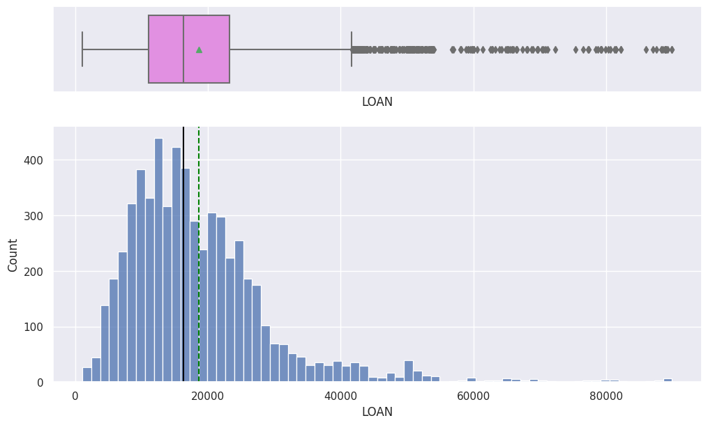

```python
# run the function to plot a boxplot and a histogram of LOAN
histogram_boxplot(df_imputed, "LOAN")
```

**Observation:**

- The distribution is right skewed with the median lying around 16.3K.

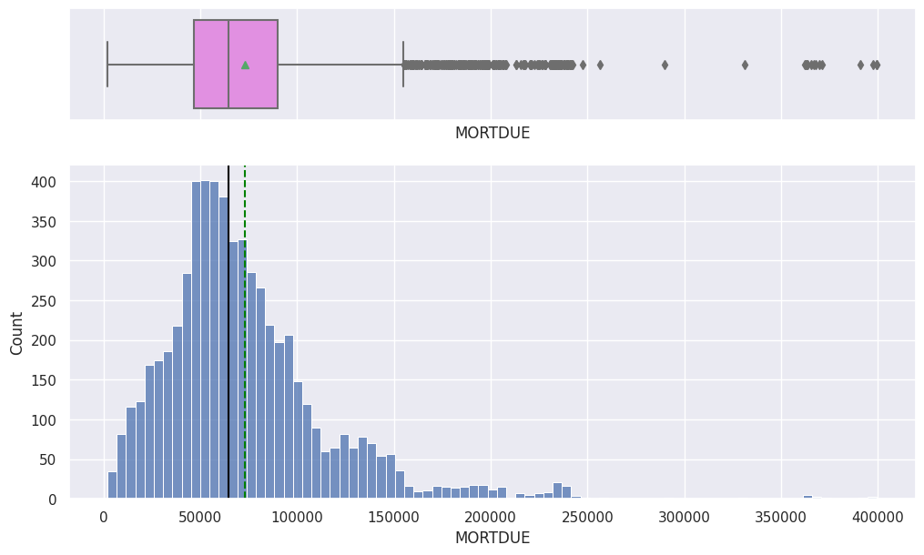

```python
# run the function to plot a boxplot and a histogram of MORTDUE
histogram_boxplot(df_imputed, "MORTDUE")
```

**Observation:**

- The distribution is right skewed with the median lying around 64.3K.

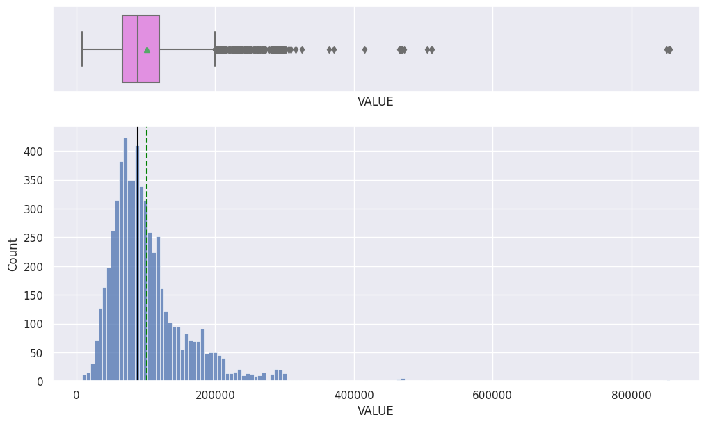

```python
# run the function to plot a boxplot and a histogram of Value
histogram_boxplot(df_imputed, "VALUE")
```

**Observation:**

- The distribution is right skewed with the median lying around 88.6K.

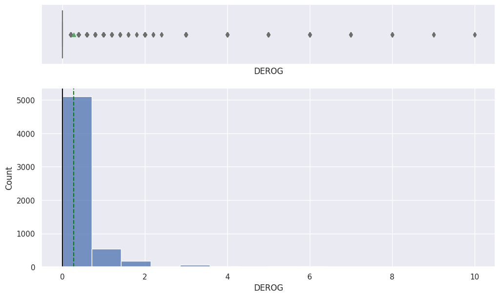

```python
# run the function to plot a boxplot and a histogram of DEROG
histogram_boxplot(df_imputed, "DEROG")
```

**Observation:**

- The distribution is right skewed with the median lying around 0, mean around 0.27 and some outliers at 10.

### **2. Univariate Analysis - Categorical Data**

```python
# Function to create barplots that indicate percentage for each category.

def perc_on_bar(plot, feature):
    '''
    plot
    feature: categorical feature
    the function won't work if a column is passed in hue parameter
    '''

    total = len(feature) # length of the column
    for p in ax.patches:
        percentage = '{:.1f}%'.format(100 * p.get_height()/total) # percentage of each class of the category
        x = p.get_x() + p.get_width() / 2 - 0.05 # width of the plot
        y = p.get_y() + p.get_height()           # height of the plot
        ax.annotate(percentage, (x, y), size = 12) # annotate the percentage

    plt.show() # show the plot
```

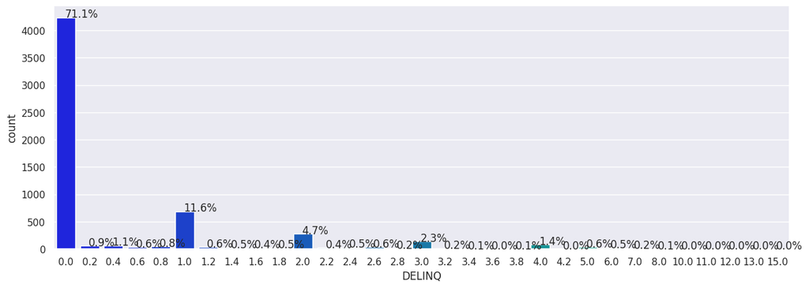

```python
#Build barplot for DELINQ

plt.figure(figsize=(15,5))
ax = sns.countplot(x=df_imputed["DELINQ"],palette='winter')
perc_on_bar(ax,df_imputed["DELINQ"])
```

**Observation:**

- **71.1% of the data show no delinquent credit lines**, while **11.6% exhibit 1 delinquent credit line**, **4.7% show 2 delinquent credit lines**, and **2.3% indicate 3 delinquent credit lines**.

## **Bivariate Analysis**

### **Bivariate Analysis: Continuous and Categorical Variables**

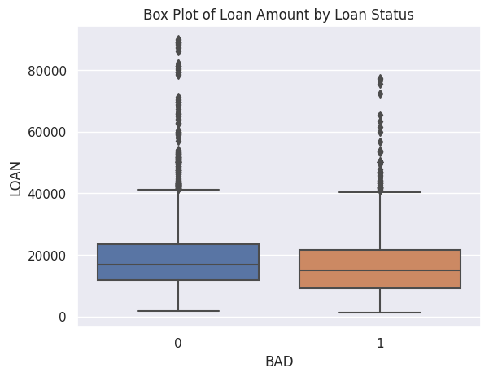

```python
# Box Plot
sns.boxplot(x='BAD', y='LOAN', data=df_imputed)
plt.title('Box Plot of Loan Amount by Loan Status')
plt.show()
```

**Observation:**

- The approved **loan amount is slightly lower for bad loans compared to good ones.**

### **Bivariate Analysis: Two Continuous Variables**

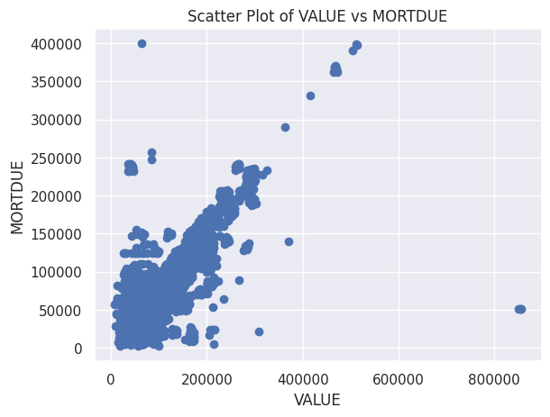

```python
# Create a scatter plot of 'VALUE' against 'MORTDUE' in the DataFrame 'df_imputed'
plt.scatter(df_imputed["VALUE"], df_imputed['MORTDUE'])

# Add any additional customization or labels if needed
# For example, you can add labels and title like this:
plt.xlabel('VALUE')
plt.ylabel('MORTDUE')
plt.title('Scatter Plot of VALUE vs MORTDUE')

# Display the plot
plt.show()
```

**Observation:**

- A **robust positive correlation exists between home value and mortgage due**. This correlation is logical, considering that more expensive homes necessitate larger mortgage loans, and larger loans typically entail longer repayment periods.

### **Bivariate Analysis: BAD vs Categorical Variables**

**The stacked bar chart (aka stacked bar graph)** extends the standard bar chart from looking at numeric values across one categorical variable to two.

```python
### Function to plot stacked bar charts for categorical columns

def stacked_plot(x):
    sns.set(palette='nipy_spectral')
    tab1 = pd.crosstab(x,df_imputed['BAD'],margins=True)
    print(tab1)
    print('-'*120)
    tab = pd.crosstab(x,df_imputed['BAD'],normalize='index')
    tab.plot(kind='bar',stacked=True,figsize=(10,5))
    plt.legend(loc='lower left', frameon=False)
    plt.legend(loc="upper left", bbox_to_anchor=(1,1))
    plt.show()
```

```
BAD         0     1   All
REASON
DebtCon  3183   745  3928
HomeImp  1384   396  1780
All      4567  1141  5708
------------------------------------------------------------------------------------------------------------------------
```

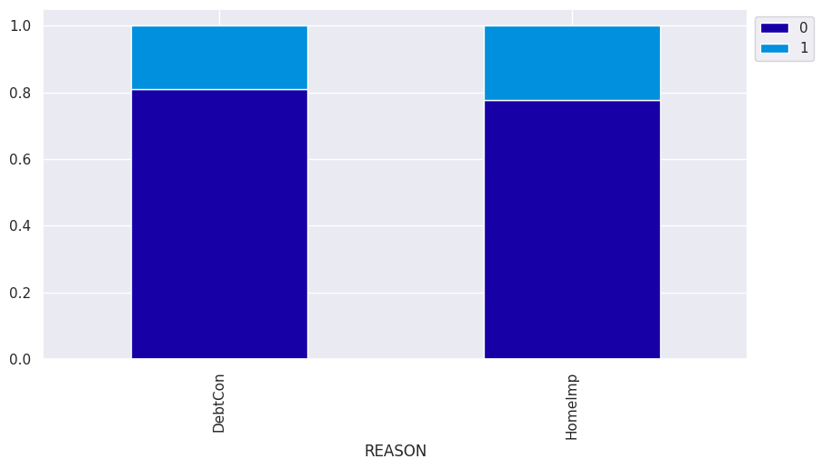

```python
# Plot stacked bar plot for BAD and REASON
stacked_plot(df['REASON'])
```

**Observations:**

### **Multivariate Analysis**

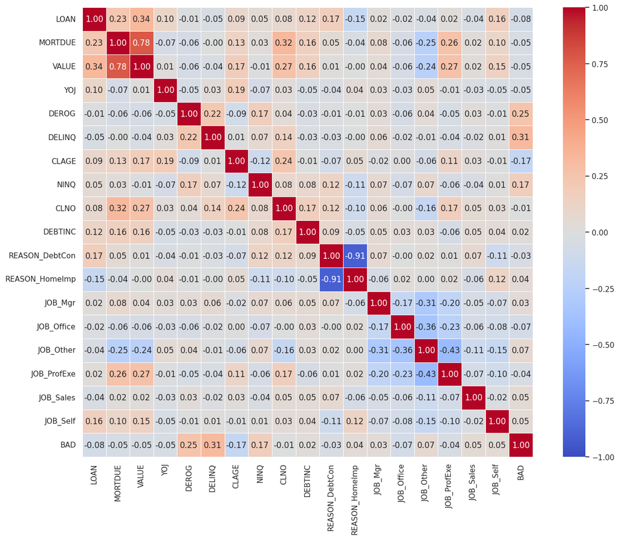

```python
# Separating numerical variables
numerical_cols = df_imputed.select_dtypes(include=np.number).columns.tolist()

# Build correlation matrix for numerical columns
corr = df_imputed[numerical_cols].corr()

# plot the heatmap with correlation values
plt.figure(figsize=(16, 12))
sns.heatmap(corr, cmap='coolwarm', annot=True, fmt=".2f", linewidths=.5,
            vmax=1, vmin=-1, square=True,
            xticklabels=corr.columns,
            yticklabels=corr.columns);
```

**Observations:**

**Loan Characteristics:**

- There is a moderate positive correlation between the loan amount ('LOAN') and the home value ('VALUE') with a correlation coefficient of 0.34. This suggests that, on average, larger loans are associated with higher home values. The correlation between 'LOAN' and 'MORTDUE' (mortgage due) is 0.23, indicating a positive relationship. Individuals with larger mortgage dues may tend to secure larger loans.

**Credit History:**

- The 'BAD' variable, representing loan default, shows a noteworthy positive correlation with 'DEROG' (derogatory reports) and 'DELINQ' (number of delinquent credit lines), with correlation coefficients of 0.25 and 0.31, respectively. **This implies that a history of derogatory reports and delinquent credit lines is associated with a higher likelihood of loan default.**
- The correlation between 'BAD' and 'NINQ' (number of recent credit inquiries) is 0.17, indicating a mild positive relationship. **More recent credit inquiries may be associated with a higher risk of loan default.**
- **VALUE (-0.045380):** The weak negative correlation between 'VALUE' and 'BAD' suggests that as the appraised value of the property decreases, there is a slight increase in the risk of a bad loan. **This might indicate that individuals with lower-valued properties could be at a slightly higher risk of default.**
- **DEROG (0.254225)**: The moderate positive correlation with 'DEROG' implies a noteworthy association between the number of derogatory reports and the likelihood of a bad loan. **Borrowers with a higher count of derogatory reports are more likely to have a bad loan. This highlights the importance of considering an applicant's credit history in assessing loan risk.**
- **CLAGE (-0.165874):** The moderate negative correlation with 'CLAGE' suggests that a longer credit history, represented by the age of the oldest trade line, is associated with a lower risk of a bad loan. **Borrowers with a well-established credit history are less likely to default. Lenders may see a longer credit history as a positive indicator of creditworthiness.**

## Treating Outliers

```python
import numpy as np

def treat_outliers(df, col):
    '''
    Treats outliers in a variable
    col: str, name of the numerical variable
    df: data frame
    '''
    Q1 = df[col].quantile(0.25)
    Q3 = df[col].quantile(0.75)
    IQR = Q3 - Q1
    Lower_Whisker = Q1 - 1.5 * IQR
    Upper_Whisker = Q3 + 1.5 * IQR
    df[col] = np.clip(df[col], Lower_Whisker, Upper_Whisker)
    return df

def treat_outliers_all(df, col_list, exclude_cols=[]):
    '''
    Treat outlier in all numerical variables, excluding specified columns
    col_list: list of numerical variables
    exclude_cols: list of columns to exclude from outlier treatment
    df: data frame
    '''
    for c in col_list:
        if c not in exclude_cols:
            df = treat_outliers(df, c)

    return df

# Create a copy of the original DataFrame (df_imputed)
df_raw = df_imputed.copy()

# Identify numerical columns
numerical_col = df_raw.select_dtypes(include=np.number).columns.tolist()

# Specify columns to exclude from outlier treatment (categorical columns)
exclude_cols = ['REASON_DebtCon', 'REASON_HomeImp', 'JOB_Mgr', 'JOB_Office', 'JOB_Other', 'JOB_ProfExe', 'JOB_Sales', 'JOB_Self', "BAD"]

# Treat outliers in numerical columns excluding specified columns
df = treat_outliers_all(df_raw, numerical_col, exclude_cols)
```

```python
df = df_imputed
df
```

|  | LOAN | MORTDUE | VALUE | YOJ | DEROG | DELINQ | CLAGE | NINQ | CLNO | DEBTINC | REASON_DebtCon | REASON_HomeImp | JOB_Mgr | JOB_Office | JOB_Other | JOB_ProfExe | JOB_Sales | JOB_Self | BAD |
| --- | --- | --- | --- | --- | --- | --- | --- | --- | --- | --- | --- | --- | --- | --- | --- | --- | --- | --- | --- |
| 0 | 1100.0 | 25860.0 | 39025.0 | 10.5 | 0.0 | 0.0 | 94.366667 | 1.0 | 9.0 | 23.314070 | 0.0 | 1.0 | 0.0 | 0.0 | 1.0 | 0.0 | 0.0 | 0.0 | 1 |
| 1 | 1300.0 | 70053.0 | 68400.0 | 7.0 | 0.0 | 2.0 | 121.833333 | 0.0 | 14.0 | 39.704157 | 0.0 | 1.0 | 0.0 | 0.0 | 1.0 | 0.0 | 0.0 | 0.0 | 1 |
| 2 | 1500.0 | 13500.0 | 16700.0 | 4.0 | 0.0 | 0.0 | 149.466667 | 1.0 | 10.0 | 36.196050 | 0.0 | 1.0 | 0.0 | 0.0 | 1.0 | 0.0 | 0.0 | 0.0 | 1 |
| 3 | 1500.0 | 48080.6 | 58891.4 | 6.8 | 0.6 | 0.8 | 110.973073 | 0.6 | 12.6 | 27.796030 | 0.0 | 0.0 | 0.0 | 0.0 | 0.0 | 0.0 | 0.0 | 0.0 | 1 |
| 4 | 1700.0 | 97800.0 | 112000.0 | 3.0 | 0.0 | 0.0 | 93.333333 | 0.0 | 14.0 | 34.370509 | 0.0 | 1.0 | 0.0 | 1.0 | 0.0 | 0.0 | 0.0 | 0.0 | 0 |
| ... | ... | ... | ... | ... | ... | ... | ... | ... | ... | ... | ... | ... | ... | ... | ... | ... | ... | ... | ... |
| 5955 | 88900.0 | 57264.0 | 90185.0 | 16.0 | 0.0 | 0.0 | 221.808718 | 0.0 | 16.0 | 36.112347 | 1.0 | 0.0 | 0.0 | 0.0 | 1.0 | 0.0 | 0.0 | 0.0 | 0 |
| 5956 | 89000.0 | 54576.0 | 92937.0 | 16.0 | 0.0 | 0.0 | 208.692070 | 0.0 | 15.0 | 35.859971 | 1.0 | 0.0 | 0.0 | 0.0 | 1.0 | 0.0 | 0.0 | 0.0 | 0 |
| 5957 | 89200.0 | 54045.0 | 92924.0 | 15.0 | 0.0 | 0.0 | 212.279697 | 0.0 | 15.0 | 35.556590 | 1.0 | 0.0 | 0.0 | 0.0 | 1.0 | 0.0 | 0.0 | 0.0 | 0 |
| 5958 | 89800.0 | 50370.0 | 91861.0 | 14.0 | 0.0 | 0.0 | 213.892709 | 0.0 | 16.0 | 34.340882 | 1.0 | 0.0 | 0.0 | 0.0 | 1.0 | 0.0 | 0.0 | 0.0 | 0 |
| 5959 | 89900.0 | 48811.0 | 88934.0 | 15.0 | 0.0 | 0.0 | 219.601002 | 0.0 | 16.0 | 34.571519 | 1.0 | 0.0 | 0.0 | 0.0 | 1.0 | 0.0 | 0.0 | 0.0 | 0 |

5960 rows × 19 columns

## **Model Building - Approach**

- Data preparation
- Partition the data into train and test set
- Build the model
- Fit on the train data
- Tune the model
- Test the model on test set

## **Data Preparation**

### **Separating the target variable from other variables**

```python
# Drop the dependent variable from the dataframe and create the X (independent variable) matrix
X = df.drop('BAD', axis=1)  # Assuming 'BAD' is your dependent variable

# Create dummy variables for the categorical variables - Hint: use the get_dummies() function
X = pd.get_dummies(X)

# Create y (dependent variable)
y = df['BAD']
```

```python
from sklearn.model_selection import train_test_split

# Split the data into training and test set
X_train, X_test, y_train, y_test = train_test_split(X, y, test_size=0.2, random_state=42, stratify=y)
```

**Impact of Split Ratio:**

- 70:30 vs. 80:20: A larger training set (80:20) may provide more data for the model to learn from, potentially resulting in better performance. However, it comes at the cost of having less data for testing. On the other hand, a smaller training set (70:30) may lead to faster training but might result in a less robust model.

**Impact on Model Performance:**

- More Training Data: Increasing the training set size can be beneficial when you have a large amount of data. It may lead to better model generalization, especially if your model is complex and has many parameters to learn. More Testing Data: Having more testing data allows for a more reliable estimate of how well your model will perform on new, unseen data. This is crucial for assessing the model's generalization ability.

**Imbalanced Data:**

- If your data is imbalanced (i.e., one class is much more frequent than the other), it's important to ensure that both the training and testing sets maintain the same class distribution. This can be achieved by using the stratify parameter in train_test_split.

In summary, it's a good practice to experiment with different split ratios and assess their impact on model performance. Additionally, when dealing with imbalanced data, maintaining class balance in both sets is crucial for a more accurate evaluation of the model's performance.

## **Model Evaluation Criterion**

#### After understanding the problem statement, think about which evaluation metrics to consider and why.

```python
from sklearn.metrics import classification_report, confusion_matrix
import seaborn as sns
import matplotlib.pyplot as plt

# Creating metric function
def metrics_score(actual, predicted):
    print(classification_report(actual, predicted))
    cm = confusion_matrix(actual, predicted)
    plt.figure(figsize=(8, 5))
    sns.heatmap(cm, annot=True, fmt='.2f', xticklabels=['Not Default', 'Default'], yticklabels=['Not Default', 'Default'])
    plt.ylabel('Actual')
    plt.xlabel('Predicted')
    plt.show()
```

### Logistic Regression

```python
from sklearn.linear_model import LogisticRegression

# Defining the Logistic regression model
model = LogisticRegression(random_state=42)

# Fitting the model on the training data
model.fit(X_train, y_train)
```

```
LogisticRegression(random_state=42)
```

```
              precision    recall  f1-score   support

           0       0.80      1.00      0.89      3817
           1       0.00      0.00      0.00       951

    accuracy                           0.80      4768
   macro avg       0.40      0.50      0.44      4768
weighted avg       0.64      0.80      0.71      4768
```

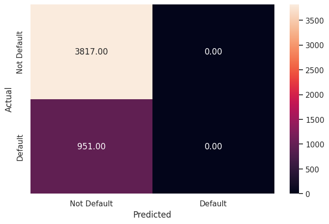

```python
# Predict for the train set
y_train_pred = model.predict(X_train)

# Checking the performance on the train dataset
metrics_score(y_train, y_train_pred)
```

**Observation:**

- The Logistic Model is giving a 0% score for category 1.

```
              precision    recall  f1-score   support

           0       0.80      1.00      0.89       954
           1       0.00      0.00      0.00       238

    accuracy                           0.80      1192
   macro avg       0.40      0.50      0.44      1192
weighted avg       0.64      0.80      0.71      1192
```

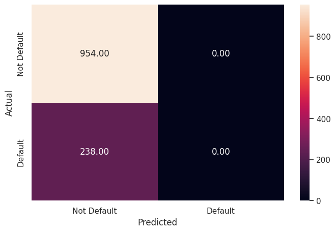

```python
# Predict for the test set
y_test_pred = model.predict(X_test)

# Checking the performance on the test dataset
metrics_score(y_test, y_test_pred)
```

**Observation:**

- The Logistic Model is giving a 0% score for category 1.

```python
# Printing the coefficients of logistic regression
coefficients = pd.DataFrame({'Variable': X.columns, 'Coefficient': model.coef_[0]})
print(coefficients)
```

```
          Variable   Coefficient
0             LOAN -1.700910e-05
1          MORTDUE -3.892747e-06
2            VALUE  1.606627e-06
3              YOJ -1.987067e-04
4            DEROG  5.441710e-05
5           DELINQ  9.586024e-05
6            CLAGE -5.753148e-03
7             NINQ  6.447816e-05
8             CLNO -1.301337e-04
9          DEBTINC -3.367825e-04
10  REASON_DebtCon -7.543465e-06
11  REASON_HomeImp -3.785290e-06
12         JOB_Mgr  2.561309e-06
13      JOB_Office -1.094012e-05
14       JOB_Other -2.142442e-07
15     JOB_ProfExe -3.655750e-06
16       JOB_Sales  1.942314e-06
17        JOB_Self  3.376519e-06
```

### Decision Tree

```python
# Drop the dependent variable from the dataframe and create the X (independent variable) matrix
X = df_imputed.drop('BAD', axis=1)

# Create dummy variables for the categorical variables
X = pd.get_dummies(X)

# Create y (dependent variable)
y = df_imputed['BAD']
```

```python
from sklearn.model_selection import train_test_split

# Split the data into training and test sets (80% train, 20% test)
X_train, X_test, y_train, y_test = train_test_split(X, y, test_size=0.2, random_state=42)
```

```python
from sklearn.tree import DecisionTreeClassifier

# Define the decision tree model with class weights
model = DecisionTreeClassifier(random_state=24, class_weight={0: 0.2, 1: 0.8})
```

```python
# Fitting the Decision Tree model on the training data
model.fit(X_train, y_train)
```

```
DecisionTreeClassifier(class_weight={0: 0.2, 1: 0.8}, random_state=24)
```

```python
# Predicting on the training data
y_train_pred = model.predict(X_train)

# Creating the confusion matrix and classification report
metrics_score(y_train, y_train_pred)
```

```
              precision    recall  f1-score   support

           0       1.00      1.00      1.00      3844
           1       1.00      1.00      1.00       924

    accuracy                           1.00      4768
   macro avg       1.00      1.00      1.00      4768
weighted avg       1.00      1.00      1.00      4768
```

**Observation:**

- The Decision tree is giving a 100% score for all metrics on the training dataset.

```
              precision    recall  f1-score   support

           0       0.89      0.94      0.91       927
           1       0.74      0.60      0.66       265

    accuracy                           0.86      1192
   macro avg       0.81      0.77      0.79      1192
weighted avg       0.86      0.86      0.86      1192
```

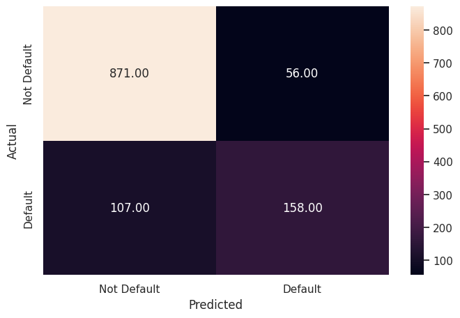

```python
# Predicting on the testing data
y_test_pred = model.predict(X_test)

# Creating the confusion matrix and classification report
metrics_score(y_test, y_test_pred)
```

**Observation:**

### **Decision Tree - Hyperparameter Tuning**

- Hyperparameter tuning is tricky in the sense that **there is no direct way to calculate how a change in the hyperparameter value will reduce the loss of your model**, so we usually resort to experimentation. We'll use Grid search to perform hyperparameter tuning.
- **Grid search is a tuning technique that attempts to compute the optimum values of hyperparameters.**
- **It is an exhaustive search** that is performed on the specific parameter values of a model.
- The parameters of the estimator/model used to apply these methods are **optimized by cross-validated grid-search** over a parameter grid.

**Criterion {“gini”, “entropy”}**

The function to measure the quality of a split. Supported criteria are “gini” for the Gini impurity and “entropy” for the information gain.

**max_depth**

The maximum depth of the tree. If None, then nodes are expanded until all leaves are pure or until all leaves contain less than min_samples_split samples.

**min_samples_leaf**

The minimum number of samples is required to be at a leaf node. A split point at any depth will only be considered if it leaves at least min_samples_leaf training samples in each of the left and right branches. This may have the effect of smoothing the model, especially in regression.

You can learn about more Hyperpapameters on this link and try to tune them.

https://scikit-learn.org/stable/modules/generated/sklearn.tree.DecisionTreeClassifier.html

#### Using GridSearchCV for Hyperparameter tuning on the model

```python
# Choose the type of classifier (e.g., DecisionTreeClassifier)
from sklearn.tree import DecisionTreeClassifier
classifier = DecisionTreeClassifier(random_state=7)

# Grid of parameters to choose from
param_grid = {
    'criterion': ['gini', 'entropy'],
    'max_depth': [None, 10, 20, 30],
    'min_samples_split': [2, 5, 10],
    'min_samples_leaf': [1, 2, 4],
    'class_weight': [{0: 0.2, 1: 0.8}, {0: 0.3, 1: 0.7}]  # Adjust the values as needed
}

# Type of scoring used to compare parameter combinations
scorer = 'f1'  # You can use other metrics like 'f1', 'precision', 'recall', etc.

# Run the grid search
from sklearn.model_selection import GridSearchCV
grid_search = GridSearchCV(classifier, param_grid, scoring=scorer, cv=5)
grid_search.fit(X_train, y_train)

# Fit the GridSearch on the train dataset
best_classifier = grid_search.best_estimator_

# Set the classifier to the best combination of parameters
classifier = grid_search.best_estimator_

# Fit the best algorithm to the data
classifier.fit(X_train, y_train)
```

```
DecisionTreeClassifier(class_weight={0: 0.3, 1: 0.7}, criterion='entropy',
                       max_depth=20, random_state=7)
```